# Part I - PROSPER LOAN DATA EXPLORATION

We would use a scatter plot since they are both numeric.

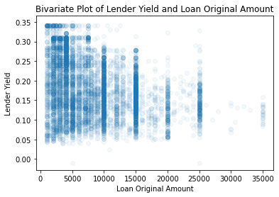

```python
scatterPlot(df_loan.sample(7000), 'LoanOriginalAmount','LenderYield',  1/20,'Loan Original Amount','Lender Yield', 'Bivariate Plot of Lender Yield and Loan Original Amount')
```

The relationship between LenderYield and LoanOriginalAmount resulted to a vertical linear relationship, that is the same amount of LoanOriginalAmount may give different Lender Yield based on what the BorrowerRate is, the equation for the plot is x=constant.

**Next we question if LenderYield is affected MonthlyLoanPayment? Since Term determines MonthlyLoanPayment and if High Term Loans are issued at higher interest, we expect LenderYield to be related to MonthlyLoanPayment.**

**Bivariate Plot of LenderYield to MonthlyLoanPayment**

We would also use a scatter plot.

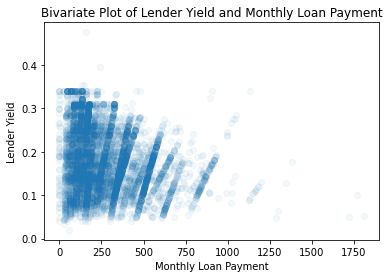

```python
scatterPlot(df_loan.sample(7000), 'MonthlyLoanPayment','LenderYield',  1/20,'Monthly Loan Payment','Lender Yield', 'Bivariate Plot of Lender Yield and Monthly Loan Payment')
```

The plot is partially a straight line graph, so we can infer that LenderYield partially increases or decreases with MonthlyLoanPayment, this results to the next question.

**Are Long Term Loans resulting to small MonthlyLoanPayment and short Term loans to High MonthlyLoanPayment?**

**Bivariate Relationship between Term and MonthlyLoanPayment**

We would also use a violin plot.

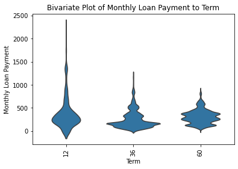

```python
violin(df_loan,'Term','MonthlyLoanPayment',base_color,None, 'Term','Monthly Loan Payment','Bivariate Plot of Monthly Loan Payment to Term')
```

Loans of term 36 and 60 have monthly loan payments that are less as compared to loans of term 12. Prosper loan portfolio is in line.

**Is Prosper's BorrowerAPR gotten from BorrowerRate?**

**Bivariate Relationship between BorrowerRate and BorrowerAPR**

We would also use a scatter plot.

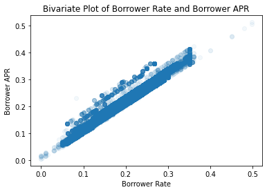

```python
scatterPlot(df_loan, 'BorrowerRate','BorrowerAPR',  1/20,'Borrower Rate','Borrower APR', 'Bivariate Plot of Borrower Rate and Borrower APR')
```

There exist a linear relationship between BorrowerRate and BorrowerAPR.

**Does Prosper give out long term loans at high interest rate and short term loans at low interest rate?**

**Bivariate Relationship between BorrowerRate and Term**

We would use a Violin plot, since we have a quantitative variable and a qualitative variable.

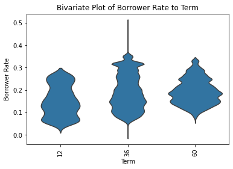

```python
violin(df_loan,'Term','BorrowerRate',base_color,None, 'Term','Borrower Rate','Bivariate Plot of Borrower Rate to Term')
```

Loans of term 60 seems to have Borrower Rate of 0.1 to 0.2 more, and it seems multimodal, same with loan of term 12. To cover the risk associated with each loan, long term loans should have high borrower rate and short term loans should have low borrower rate but this not explicit in Prosper loan's portfolio.

**Since LenderYield is a product of BorrowerRate, is ProsperScore having the same relationship that LenderYield have with ProsperScore?**

**Bivariate Relationship between BorrowerRate and ProsperScore**

We would also use a violin plot.

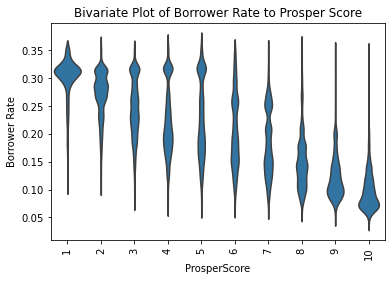

```python
violin(df_loan,'ProsperScore','BorrowerRate',base_color,None, 'ProsperScore','Borrower Rate','Bivariate Plot of Borrower Rate to Prosper Score')
```

**Is Prosper issuing high valued loans with long terms at a higher BorrowerRate?**

**Bivariate Relationship between BorrowerRate and LoanOriginalAmount**

The two are numeric so we would use a scatter plot.

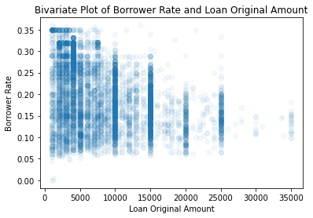

```python
scatterPlot(df_loan.sample(7000), 'LoanOriginalAmount','BorrowerRate',  1/20,'Loan Original Amount','Borrower Rate','Bivariate Plot of Borrower Rate and Loan Original Amount')
```

They are related by the equation x=constant, i.e. no matter the value borrower rate may take loan original amount remains constant,i.e high amounts of loans are not issued at a higher Borrower rate, but Prosper needs to look into this, high value loans at short term should have lower borrower rate and high value loans at long term should have a higher borrower rate to increase yield incase of default along the process, but we are not seeing that pattern above.

**Next, is there a relationship existing between BorrowerRate and MonthlyLoanPayment?**

**Bivariate Relationship between BorrowerRate and MonthlyLoanPayment**

We would also use a scatter plot.

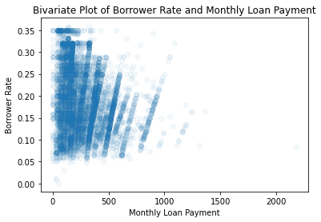

```python
scatterPlot(df_loan.sample(7000), 'MonthlyLoanPayment','BorrowerRate',  1/20,'Monthly Loan Payment','Borrower Rate','Bivariate Plot of Borrower Rate and Monthly Loan Payment')
```

It has the same relationship that is existing between LenderYield and MonthlyLoanPayment and this is because LenderYield is a product of BorrowerRate. This implies that monthly loan payment is partially determined by the BorrowerRate.

**Is Prosper having the right mix of LoanOriginalAmount and Term?**

**Bivariate Relationship between Term and LoanOriginalAmount**

It is a numeric set and a qualitative set, so we would use a violin plot.

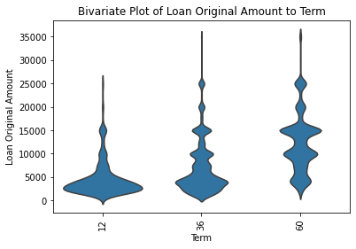

```python
violin(df_loan,'Term','LoanOriginalAmount',base_color,None, 'Term','Loan Original Amount','Bivariate Plot of Loan Original Amount to Term')
```

Loans of term 12 have values 0.1 to 5000 more, as the violin is looking fat at this region.High amount of loans seem to have term 36 and 60 and low amount of loans seem to have term 12. Depending on what Prosper mission is in the finance industry, I think there needs to be a more balance in mix of loan amounts and term, i.e more short term loans of high figures at an appropriate interest rate should be issued.

**Is Prosper classifying high value loans at long terms as risky more than high value loans at short term?**

**Bivariate Relationship between ProsperScore and LoanOriginalAmount**

It is a categorical data and a numeric data so we would use a violin plot.

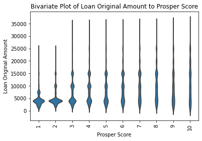

```python
violin(df_loan,'ProsperScore','LoanOriginalAmount',base_color,None, 'Prosper Score','Loan Original Amount','Bivariate Plot of Loan Original Amount to Prosper Score')
```

Prosper has more risky loans lieing between 0-5000 loan original amount and less risky loans are with high values are not much, this needs to be taken care of, the portfolio should have diversified mix of loans but this depends on what their mission is, whether is solely profit making or poverty alleviation.

**Is Prosper classifying high value loans with low monthly payment i.e long term as more risky?**

**Bivariate Relationship between ProsperScore and MonthlyLoanPayment**

We would also use a Violin plot.

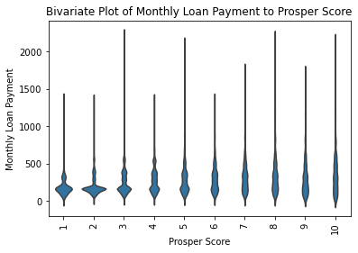

```python
violin(df_loan,'ProsperScore','MonthlyLoanPayment',base_color,None, 'Prosper Score','Monthly Loan Payment','Bivariate Plot of Monthly Loan Payment to Prosper Score')
```

More risky loans have small values of monthly loan payment, as can be seen loans of score 1 -3 (high risk) have a monthly loan payment of 0-500,which is not appreciable, but before we conclude we need to see the relationship between the two variables and LoanOriginalAmount.

**Are higher value loans having higher monthly repayment?**

**Bivariate Relationship between LoanOriginalAmount and MonthlyLoanPayment**

They are both numeric data sets so we would use a scatter plot.

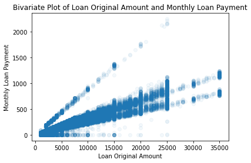

```python
scatterPlot(df_loan, 'LoanOriginalAmount','MonthlyLoanPayment',  1/20,'Loan Original Amount','Monthly Loan Payment','Bivariate Plot of Loan Original Amount and Monthly Loan Payment')
```

From the plot, it is obvious that some Prosper loans of 35000 are having monthly repayment amount almost same with some loans of 20000, 25000 and 35000, which is not ok, larger loan amounts should have larger monthly loan payment amount to reduce the risk of such loans, but this depends of what the loan term is, hence there is need to see the multivariate plot of monthly loan payment, loan original amount and term.

**Is Prosper estimating loss associated with each issued loan appropriately?**

**Bivariate Relationship between BorrowerAPR and EstimatedLoss**

They are both numeric data sets, so we would use a scatter plot.

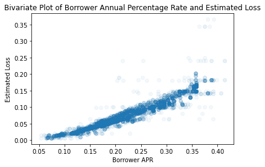

```python
scatterPlot(df_loan.sample(7000), 'BorrowerAPR','EstimatedLoss',  1/20,'Borrower APR','Estimated Loss','Bivariate Plot of Borrower Annual Percentage Rate and Estimated Loss')
```

It appears that there exist an inconspicuous relationship between estimated loss and borrower's annual percentage rate. It appears like loans with high APR have high estimated loss, this needs to be proven further by viewing the relationship between borrower Rate and Estimated Loss since BorrowerAPR is a product of BorrowerRate.

**Is Estimated Return affected by the Borrower's Annual Percentage Rate?**

**Bivariate Relationship between BorrowerAPR and EstimatedReturn**

We would also use a scatter plot.

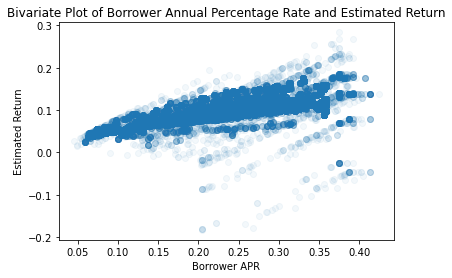

```python
scatterPlot(df_loan, 'BorrowerAPR','EstimatedReturn',  1/20,'Borrower APR','Estimated Return','Bivariate Plot of Borrower Annual Percentage Rate and Estimated Return')
```

The borrower APR is related to Estimated Return as can be seen, some high APR's were giving a negative returns whereas majority of APR's were giving a return greater than 0.

**Is EstimatedLoss a product of BorrowerRate?**

**Bivariate Relationship between BorrowerRate and EstimatedLoss**

We would use a scatter plot.

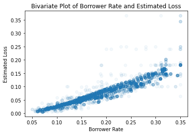

```python
scatterPlot(df_loan.sample(7000), 'BorrowerRate','EstimatedLoss',  1/20,'Borrower Rate','Estimated Loss','Bivariate Plot of Borrower Rate and Estimated Loss')
```

There exist a linear relationship between the two variables but it isn't absolute. High Borrower rates yield higher estimated loss and lower borrower rate yield low estimated loss

**Is EstimatedReturn a product of BorrowerRate?**

**Bivariate Relationship between BorrowerRate and EstimatedReturn**

We would use a scatter plot.

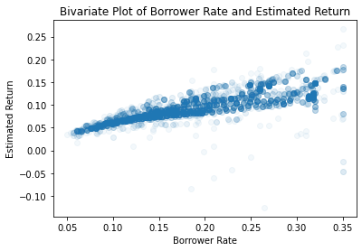

```python
scatterPlot(df_loan.sample(7000), 'BorrowerRate','EstimatedReturn',  1/20,'Borrower Rate','Estimated Return','Bivariate Plot of Borrower Rate and Estimated Return')
```

There also appears to be a linear relationship between the two variables but it isn't absolute.

**Is Prosper a profit making venture or a poverty alleviation venture?**

**Bivariate Relationship between BorrowerRate and DebtToIncomeRatio**

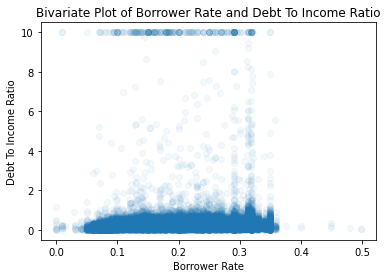

```python
scatterPlot(df_loan, 'BorrowerRate','DebtToIncomeRatio',  1/20,'Borrower Rate','Debt To Income Ratio','Bivariate Plot of Borrower Rate and Debt To Income Ratio')
```

The y axis variable seems to be constant at 0 or 10 no matter the value Borrower rate. Prosper is not considering the customers debt to income ratio in marking out borrower rates for loans, it is saliently implied that their mission may not be poverty alleviation but profit making, as majority of points reside at debt to income ratio of 0.

**Are long term loans having more on time payments than short term loans?**

**Bivariate Relationship between Term and OnTimeProsperPayments**

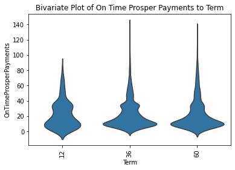

```python
violin(df_loan,'Term','OnTimeProsperPayments',base_color,None, 'Term','OnTimeProsperPayments','Bivariate Plot of On Time Prosper Payments to Term')
```

Loans of term 60 and 36 have more on time payments of 0-20 than loans of term 12 but loans of term 12 have on time payments 20-40 more than the both. Recall that from above that univariate exploration that loans of term 36 have a higher frequency in Prosper loans. Loan terms does not explicitly affect on time payments.

**Are less risky loans having more on time payments than more risky loans?**

**Bivariate Relationship between ProsperScore and OnTimeProsperPayments**

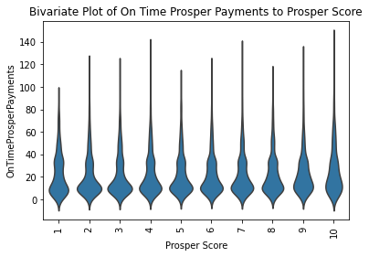

```python
violin(df_loan,'ProsperScore','OnTimeProsperPayments',base_color,None, 'Prosper Score','OnTimeProsperPayments','Bivariate Plot of On Time Prosper Payments to Prosper Score')
```

Less risky loans have a higher value of on time payments but it isn't absolute.

**Does ProsperPrincipalBorrowed in any way determine ProsperPrincipalOutstanding?**

**Bivariate Relationship between Prosper Principal Borrowed and Prosper Principal Outstanding**

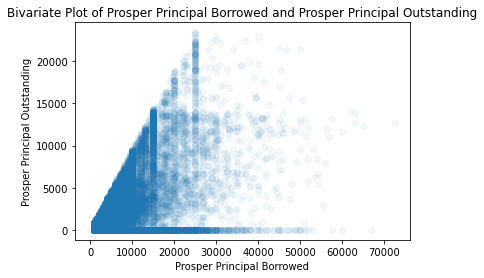

```python
scatterPlot(df_loan, 'ProsperPrincipalBorrowed','ProsperPrincipalOutstanding',  1/20,'Prosper Principal Borrowed','Prosper Principal Outstanding','Bivariate Plot of Prosper Principal Borrowed and Prosper Principal Outstanding')
```

They seem to have a relationship where 'Prosper Principal Outstanding' remains constant for whatever principal value borrowed and then it also seems to have a linear relationship.

**Is Prosper considering outstanding principal issuing out loans of certain terms?**

**Bivariate Plot of Term and ProsperPrincipalOutstanding**

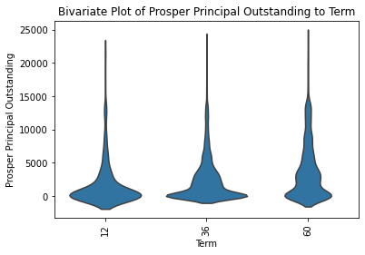

```python
violin(df_loan,'Term','ProsperPrincipalOutstanding',base_color,None, 'Term','Prosper Principal Outstanding','Bivariate Plot of Prosper Principal Outstanding to Term')
```

Majority of customers who have low outstanding principal were given loans of term 12 and 36 and majority of customers who have high outstanding principal were given loan of term 60. At this point, it seems Prosper is also a poverty alleviating venture.

**Which loan term have the least gross principal charged off amount?**

**Bivariate Plot of Term and LP_GrossPrincipalLoss**

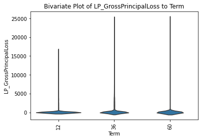

```python
violin(df_loan,'Term','LP_GrossPrincipalLoss',base_color,None, 'Term','LP_GrossPrincipalLoss','Bivariate Plot of LP_GrossPrincipalLoss to Term')
```

Customers with short term loans have the gross principal charged off on the loan lesser than customers with long term loans.

_**Is LP_NetPrincipalLoss a product of LP_GrossPrincipalLoss?**_

**Bivariate Plot of LP_NetPrincipalLoss and Term**

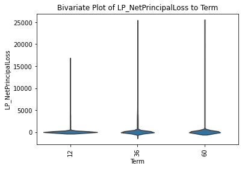

```python
violin(df_loan,'Term','LP_NetPrincipalLoss',base_color,None, 'Term','LP_NetPrincipalLoss','Bivariate Plot of LP_NetPrincipalLoss to Term')
```

It has the same result with as with LP_GrossPrincipalLoss.

**Which loan term have more investment from friends amount?**

**Bivariate Plot of InvestmentFromFriendsAmount and Term**

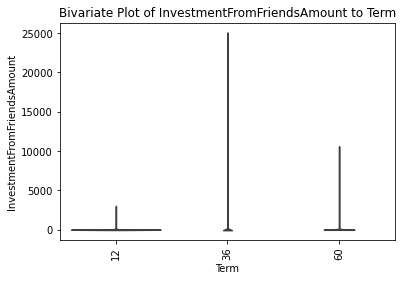

```python
violin(df_loan,'Term','InvestmentFromFriendsAmount',base_color,None, 'Term','InvestmentFromFriendsAmount','Bivariate Plot of InvestmentFromFriendsAmount to Term')
```

Prosper is adviced to engage more friends of borrowers in investing in their loan especially loans of long term in order to reduce the gross and net principal loss values of loans of term 36 and 60.

**Is there a particular loan term that it's loans are completed than others?**

**Bivariate Plot of Loan Status and Term**

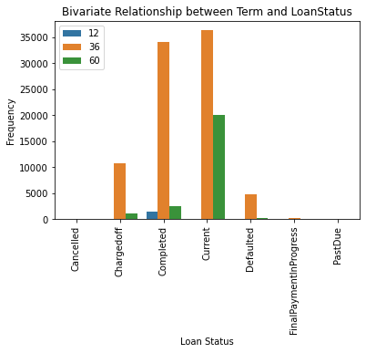

```python
clusteredBarChart(df_loan,  'LoanStatus', 'Term', "Loan Status","Frequency","Bivariate Relationship between Term and LoanStatus")
plt.xticks(rotation=90)
plt.legend(loc='upper left')
```

Loans of term 12 have less running, less defaulted, none past due, none chargedoff and none cancelled. Prosper is adviced to give more of loans of term 12. And come at the middle concerning loans of term 36 and 60 as they have high risk.

**Loans classified as less risky where they completed more than loans classified as risky?**

**Bivariate Relationship between ProsperScore and LoanStatus**

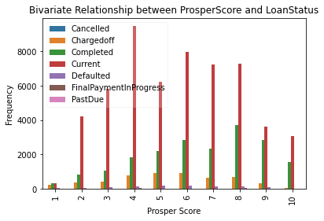

```python
clusteredBarChart(df_loan,  'ProsperScore', 'LoanStatus', "Prosper Score","Frequency","Bivariate Relationship between ProsperScore and LoanStatus")
plt.xticks(rotation=90)
plt.legend(loc='upper left',framealpha=0.2)
```

Less risky loans have more completed status and more risky loans have lesser population, this is in order but improvement is needed, loans of score 10 and 9 should be increased. Also the proportion of loan of status current and completed in loans of term 4 is not appreciable, this should be worked on.

**Does the borrower rate affect if a loan will be completed or not?**

**Bivariate Plot of LoanStatus and BorroweRate**

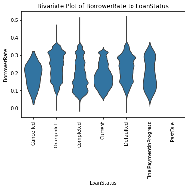

```python
violin(df_loan,'LoanStatus','BorrowerRate',base_color,None, 'LoanStatus','BorrowerRate','Bivariate Plot of BorrowerRate to LoanStatus')
```

Cancelled loans are more in the lower end of [0.2,0.3], It seems that loans with higher borrower rate are charged off, i.e. rate of 0.3 and also loans of higher borrower rate are completed but the population is lesser in comparison to charged off, loans of higher range of [0.2,0.3] are defaulted and we have more loans in the final payment in progress status and no past due loans. From this Prosper portfolio seems to be healthy, but improvement is needed, borrower rate should be reduced by making the loans which are short term to have a more higher population of completed loans at the lower end of the borrower rate.

**Are loans with high lender yield completed?**

**Bivariate Plot of LoanStatus and LenderYield**

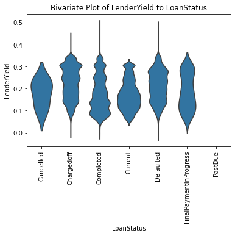

```python
violin(df_loan,'LoanStatus','LenderYield',base_color,None, 'LoanStatus','LenderYield','Bivariate Plot of LenderYield to LoanStatus')
```

From observation, cancelled status is fat at the lower end of [0.2,0.3], charged off is fat at the 0.3 plus and completed is fat at 0.1 plus and the upper end of [0.0,0.1], from this observation, we advice Prosper to give more loans of lesser yield that is less borrower rate, since they have a tendency of being completed than those with high yield.

**Are high value loans actually completed?**

**Bivariate Plot of LoanOriginalAmount and LoanStatus**

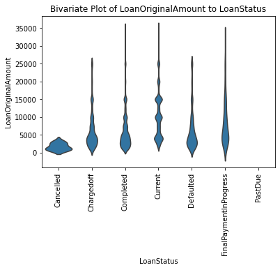

```python
violin(df_loan,'LoanStatus','LoanOriginalAmount',base_color,None, 'LoanStatus','LoanOriginalAmount','Bivariate Plot of LoanOriginalAmount to LoanStatus')
```

More lesser loans are cancelled, charged off, completed, defaulted and in the final payment in progress than higher loans, no pattern is observed explicitly, but on the above plot, Prosper is adviced to give more loans within [10000,25000] than loans within [0,5000] and reduce the risk associated with them by making them short term loans i.e. monthly loan payments of higher figures, this will be best visualized in a multivariate plot of loan original amount, loan status and monthly loan payment.

**Is monthly loan payment having the same relationship loan original amount is having loan status?**

**Bivariate Plot of LoanStatus and MonthlyLoanPayment**

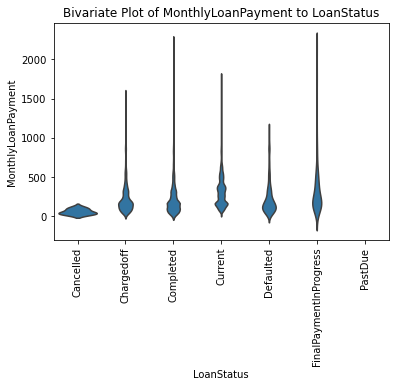

```python
violin(df_loan,'LoanStatus','MonthlyLoanPayment',base_color,None, 'LoanStatus','MonthlyLoanPayment','Bivariate Plot of MonthlyLoanPayment to LoanStatus')
```

We have the result above, because we have smaller loans in our portfolio than higher loans.

**Does the income level of customers affect their ability to complete loan payments?**

**Bivariate Plot og LoanStatus and StatedMonthlyIncome**

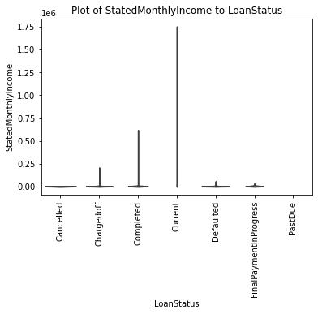

```python
violin(df_loan,'LoanStatus','StatedMonthlyIncome',base_color,None, 'LoanStatus','StatedMonthlyIncome','Plot of StatedMonthlyIncome to LoanStatus')
```

Most Prosper customers are low income earners, no wonder the [0-5000] high population of loan original amount. To have higher profits, Prosper needs to take more risk by giving out higher loans to high income earners backed properly by friends investment.

**Is Prosper portfolio healthy in terms of issuing less loans to customers with high principal outstanding?**

**Bivariate Plot of ProsperPrincipalOutstanding against TotalProsperLoans**

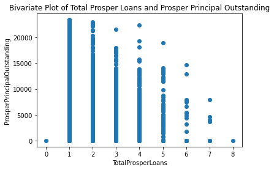

```python
scatterPlot(df_loan, 'TotalProsperLoans','ProsperPrincipalOutstanding',  1,'TotalProsperLoans','ProsperPrincipalOutstanding','Bivariate Plot of Total Prosper Loans and Prosper Principal Outstanding')
```


## Multivariate Exploration

**Multivariate Plot of MonthlyLoanPayment, BorrowerRate and LoanStatus**

The dataset is two numeric datasets and one nominal dataset so we would use a faceted scatter plot and handle overplotting with sampling.

```python
'''Function to create a faceted scatter plot
    df: the dataframe to pull the data from
    hueColumn: The categorical column
    siz: The size of the facet
    colX: Numeric column on the x axis
    colY: Numeric column on the y axis
    xscale: The scale transform to apply to x axis
    yscale: The scale transform to apply to y axis
    xticks: The ticks to be used on the x axis
    yticks: The ticks to be used on the y axis
    palete: The color palete to use for the hueColumn
    alpha: The transparency value of the scatter plot
'''
def facetedScatterPlot(df, hueColumn, siz, colX, colY, xscale, yscale, xticks, yticks,palete, alpha):
    g=sb.FacetGrid(data=df,hue=hueColumn,height=siz,aspect=1.5,palette=palete)
    g.map(plt.scatter, colX, colY, alpha = alpha)
    #set the x axis transform to log if log is given
    if xscale=='log':
        g.set(xscale='log')
    #set the y axis transform to log if log is given
    if yscale=='log':
        g.set(xscale='log')
    #if xticks is not an empty list, set the xtick
    if xticks != []:
        g.set(xticks=xticks, xticklabels=xticks)
    #if yticks is not an empty list, set the ytick
    if yticks != []:
        g.set(yticks=yticks, yticklabels=yticks)
    g.add_legend()
```

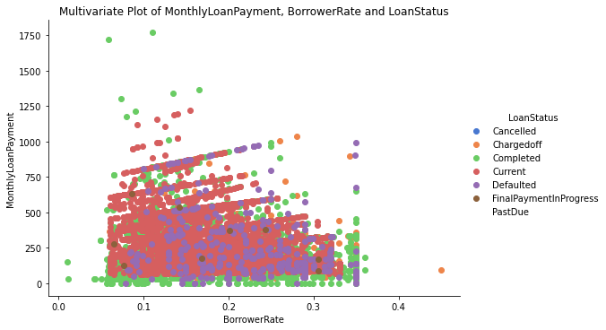

```python
facetedScatterPlot(df_loan.sample(7000), 'LoanStatus', 5, 'BorrowerRate', 'MonthlyLoanPayment', 'none', 'none', [], [],'muted');
plt.title('Multivariate Plot of MonthlyLoanPayment, BorrowerRate and LoanStatus')
plt.xlabel('BorrowerRate')
plt.ylabel('MonthlyLoanPayment')
```

**Multivariate Plot of Prosper Score, Estimated Return and Lender Yield**

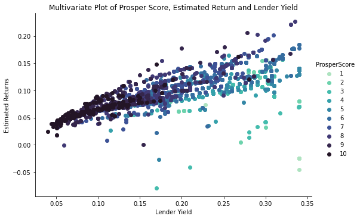

```python
facetedScatterPlot(df_loan.sample(7000), 'ProsperScore', 5, 'LenderYield', 'EstimatedReturn', 'none', 'none', [], [],'mako_r');
plt.xlabel('Lender Yield')
plt.ylabel('Estimated Returns')
plt.title('Multivariate Plot of Prosper Score, Estimated Return and Lender Yield')
```

Some Loans of higher risk were estimated to give a negative return but they turned out to give a positive yield of 0.15+. This implies that Prosper can take higher risk by issuing loans of higher risk that would give higher returns and shoulder the risk by having more friends investing in the loan as can be seen below that not much friends are investing in Prosper loans.

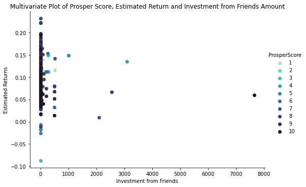

```python
facetedScatterPlot(df_loan.sample(7000), 'ProsperScore', 5, 'InvestmentFromFriendsAmount', 'EstimatedReturn', 'none', 'none', [], [],'mako_r');
plt.xlabel('Investment from Friends')
plt.ylabel('Estimated Returns')
plt.title('Multivariate Plot of Prosper Score, Estimated Return and Investment from Friends Amount')
```

As can be seen majority of loans with high estimated and negative estimated returns have 0-1000 amount from friends, Prosper needs to explore this more by reducing the risk of high loans with friends investment and accomodating high yielding loans thus.

**Multivariate Plot of EstimatedLoss, BorrowerRate and LoanStatus**

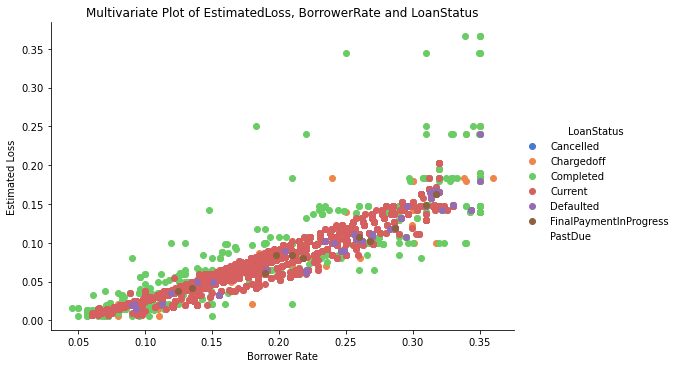

```python
facetedScatterPlot(df_loan.sample(7000), 'LoanStatus', 5, 'BorrowerRate', 'EstimatedLoss', 'none', 'none', [], [],'muted');
plt.title('Multivariate Plot of EstimatedLoss, BorrowerRate and LoanStatus')
plt.xlabel('Borrower Rate')
plt.ylabel('Estimated Loss')
```

Prosper have loans of different borrower rate running and it appears that loans of higher borrower rate are associated with higher estimated loss which is in line, but that should not discourage of risk taking, as the soul of every business is risk taking, not just risk taking but calculated risk taking.More loans of higher borrower rate that will result to high estimated returns should be issued and as can be seen that a fewer set of such loans existing were actually completed.